# Flight Traffic Forecasting

### EXPLORATORY DATA ANALYSIS

```r
library(dplyr)
library(fpp2)
```

```r
library(ggplot2)
library(urca)
```

```r
data <- read.csv("Data/US_Monthly_Air_Passengers00_19.csv")
```

```r
names(data) <- tolower(names(data))
colnames(data)
```

```
##  [1] "sum_passengers"      "airline_id"          "carrier_name"
##  [4] "origin"              "origin_city_name"    "origin_state_abr"
##  [7] "origin_state_nm"     "origin_country"      "origin_country_name"
## [10] "dest"                "dest_city_name"      "dest_state_abr"
## [13] "dest_state_nm"       "dest_country"        "dest_country_name"
## [16] "year"                "month"
```

```r
dataus <- subset(data, origin_country == "US")
datausd <- subset(dataus, dest_country == "US")
nc <- subset(datausd, origin_state_abr == "NC" | dest_state_abr == "NC")
colnames(nc)
```

```
##  [1] "sum_passengers"      "airline_id"          "carrier_name"
##  [4] "origin"              "origin_city_name"    "origin_state_abr"
##  [7] "origin_state_nm"     "origin_country"      "origin_country_name"
## [10] "dest"                "dest_city_name"      "dest_state_abr"
## [13] "dest_state_nm"       "dest_country"        "dest_country_name"
## [16] "year"                "month"
```

```r
dim(nc)
```

```
## [1] 279509     17
```

**Checking the cumulative percentage for the total of passenger on North Carolina to determine which cities to focus on**

```r
# Calculate total passengers for each city
city_passengers <- nc %>%
  group_by(city = ifelse(origin_state_abr == "NC", origin_city_name, dest_city_name)) %>%
  summarise(total_passengers = sum(sum_passengers)) %>%
  arrange(desc(total_passengers))

# Calculate cumulative percentage of passengers
city_passengers <- city_passengers %>%
  mutate(cumulative_percent = cumsum(total_passengers) / sum(total_passengers))

head(city_passengers)
```

| city | total_passengers | cumulative_percent |
| --- | --- | --- |
| Charlotte, NC | 628498263 | 0.7097388 |
| Raleigh/Durham, NC | 183455725 | 0.9169082 |
| Greensboro/High Point, NC | 37343640 | 0.9590790 |
| Asheville, NC | 12016120 | 0.9726483 |
| Wilmington, NC | 10376409 | 0.9843660 |
| Fayetteville, NC | 5922928 | 0.9910545 |

We can see that Charlotte and Raleigh make up over 91.7% of the passengers in North Carolina.

**Filtering to only include Charlotte and Raleigh.**

```r
df <- subset(nc, origin_city_name == "Raleigh/Durham, NC" | origin_city_name == "Charlotte, NC" | dest_city_name == "Raleigh/Durham, NC" | dest_city_name == "Charlotte, NC")
dim(df)
```

```
## [1] 217683     17
```

217,683 flights.

**Checking missing values**

```r
missing_values <- colSums(is.na(df))
print(missing_values)
```

```
##      sum_passengers          airline_id        carrier_name              origin
##                   0                   5                   0                   0
##    origin_city_name    origin_state_abr     origin_state_nm      origin_country
##                   0                   0                   0                   0
## origin_country_name                dest      dest_city_name      dest_state_abr
##                   0                   0                   0                   0
##       dest_state_nm        dest_country   dest_country_name                year
##                   0                   0                   0                   0
##               month
##                   0
```

There are no relevant missing values in the data. Just 5 for airline_id, and is not going to affect our ts object.

## Data Visualizations for our EDA

**Top 15 Carriers by Number of Flights**

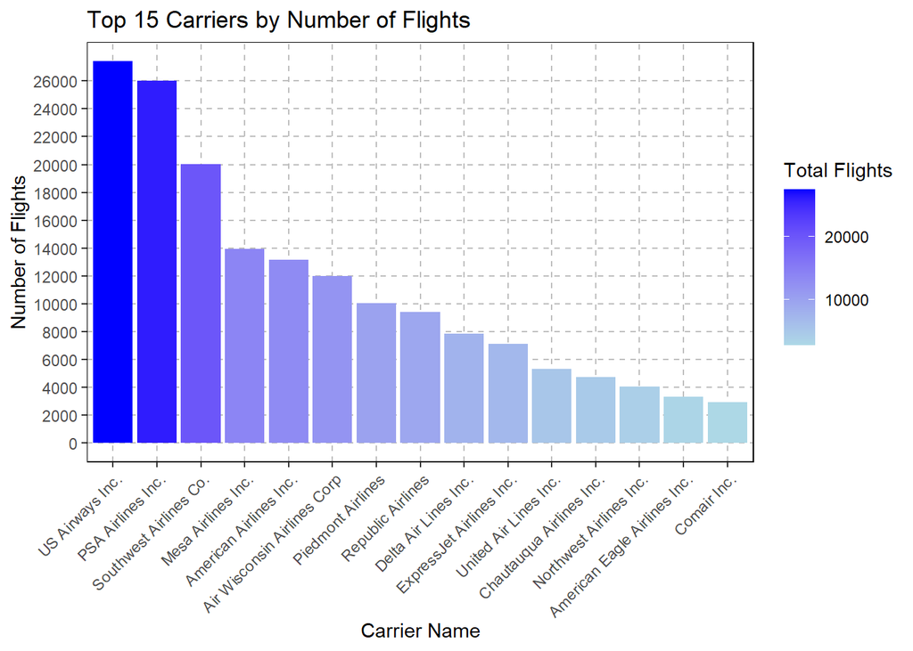

```r
top_carriers <- df %>%
  group_by(carrier_name) %>%
  summarise(number_of_flights = n()) %>%
  top_n(15, number_of_flights)

top_carriers <- top_carriers[order(-top_carriers$number_of_flights), ]

ggplot(top_carriers, aes(x = reorder(carrier_name, -number_of_flights), y = number_of_flights, fill = number_of_flights)) +
  geom_bar(stat = "identity") +
  scale_fill_gradient(low = "lightblue", high = "blue") + # Gradient from light to dark blue
  scale_y_continuous(breaks = seq(0, max(top_carriers$number_of_flights), by = 2000)) + # Custom y-axis breaks
  xlab("Carrier Name") +
  ylab("Number of Flights") +
  ggtitle("Top 15 Carriers by Number of Flights") +
  theme(axis.text.x = element_text(angle = 45, hjust = 1),
        panel.grid.major = element_line(color = "gray", linetype = "dashed"), # Add dashed major grid lines
        panel.grid.minor = element_blank(), # Remove minor grid lines to reduce clutter
        panel.background = element_blank(), # Remove panel background
        panel.border = element_rect(color = "black", fill = NA)) + # Add border around the plot
  labs(fill = "Total Flights")
```

**Top 15 Destinations by Number of Flights**

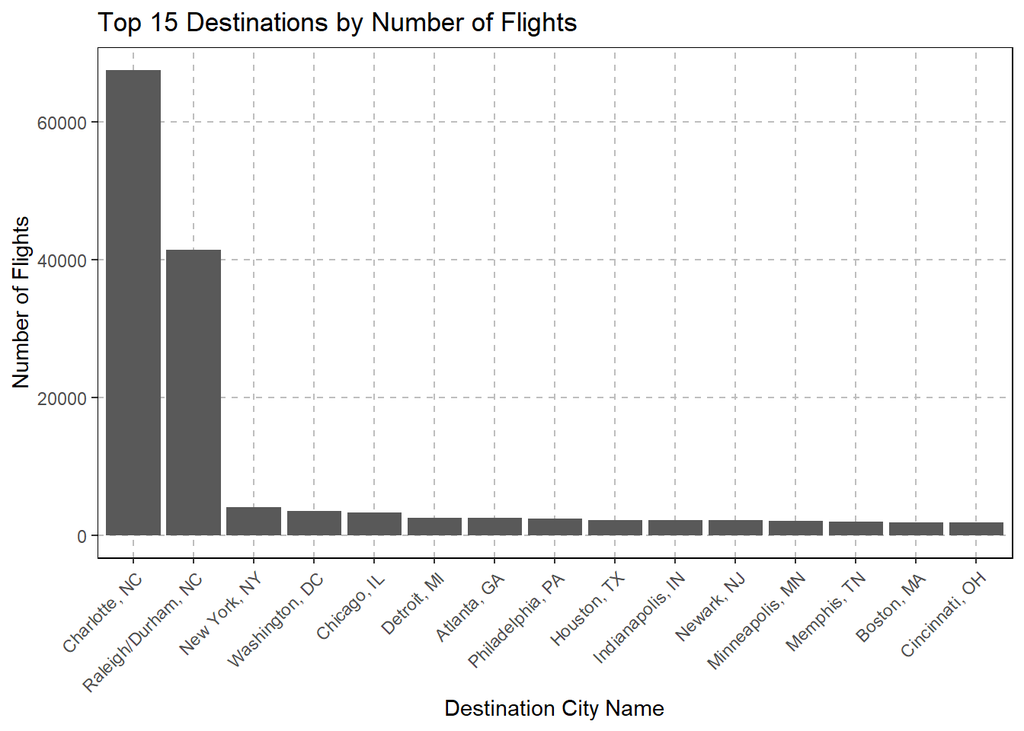

```r
top_destinations <- df %>%
  group_by(dest_city_name) %>%
  summarise(number_of_flights = n()) %>%
  top_n(15, number_of_flights)

top_destinations <- top_destinations[order(-top_destinations$number_of_flights), ]

ggplot(top_destinations, aes(x = reorder(dest_city_name, -number_of_flights), y = number_of_flights),
       fill = dest_city_name) +
  geom_bar(stat = "identity") +
  xlab("Destination City Name") +
  ylab("Number of Flights") +
  ggtitle("Top 15 Destinations by Number of Flights") +
  theme(axis.text.x = element_text(angle = 45, hjust = 1),
        panel.grid.major = element_line(color = "gray", linetype = "dashed"), # Add dashed major grid lines
        panel.grid.minor = element_blank(), # Remove minor grid lines to reduce clutter
        panel.background = element_blank(), # Remove panel background
        panel.border = element_rect(color = "black", fill = NA))  # Add border around the plot
```

Since our top destinations are Charlotte, NC and Raleigh/Durham, NC, we decide to visualize the top destinations with origin_city Charlotte, NC or Raleigh/Durham, NC

**Top 15 Destinations by Number of Flights for Charlotte, NC and Raleigh/Durham, NC**

```r
library(gridExtra)
```

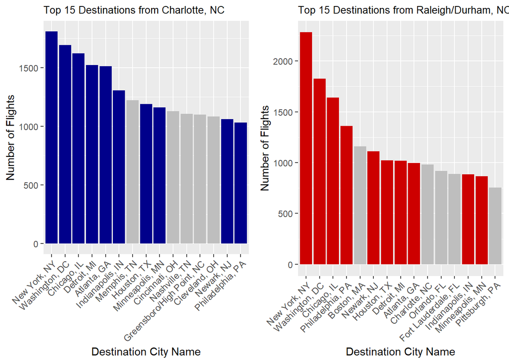

```r
# Prepare data for Charlotte, NC
top_destinations_charlotte <- df %>%
  filter(origin_city_name == "Charlotte, NC") %>%
  group_by(dest_city_name) %>%
  summarise(number_of_flights = n()) %>%
  top_n(15, number_of_flights) %>%
  arrange(desc(number_of_flights))

# Prepare data for Raleigh/Durham, NC
top_destinations_raleigh <- df %>%
  filter(origin_city_name == "Raleigh/Durham, NC") %>%
  group_by(dest_city_name) %>%
  summarise(number_of_flights = n()) %>%
  top_n(15, number_of_flights) %>%
  arrange(desc(number_of_flights))

# Identify common destinations
common_destinations <- intersect(top_destinations_charlotte$dest_city_name, top_destinations_raleigh$dest_city_name)

# Plot for Charlotte with conditional coloring
plot_charlotte <- ggplot(top_destinations_charlotte, aes(x = reorder(dest_city_name, -number_of_flights), y = number_of_flights, fill = dest_city_name %in% common_destinations)) +
  geom_bar(stat = "identity") +
  scale_fill_manual(values = c("TRUE" = "blue4", "FALSE" = "gray")) +
  xlab("Destination City Name") +
  ylab("Number of Flights") +
  ggtitle("Top 15 Destinations from Charlotte, NC") +
  theme(axis.text.x = element_text(angle = 45, hjust = 1, size = 9),  # Smaller tick labels on the x-axis
        axis.text.y = element_text(size = 9),  # Smaller tick labels on the y-axis
        plot.title = element_text(size = 10),   # Smaller plot title
        legend.position = "none")

# Plot for Raleigh/Durham with conditional coloring
plot_raleigh <- ggplot(top_destinations_raleigh, aes(x = reorder(dest_city_name, -number_of_flights), y = number_of_flights, fill = dest_city_name %in% common_destinations)) +
  geom_bar(stat = "identity") +
  scale_fill_manual(values = c("TRUE" = "red3", "FALSE" = "gray")) +
  xlab("Destination City Name") +
  ylab("Number of Flights") +
  ggtitle("Top 15 Destinations from Raleigh/Durham, NC") +
    theme(axis.text.x = element_text(angle = 45, hjust = 1, size = 9),  # Smaller tick labels on the x-axis
        axis.text.y = element_text(size = 9),  # Smaller tick labels on the y-axis
        plot.title = element_text(size = 10),   # Smaller plot title
        legend.position = "none")

# Combine both plots in a grid layout
grid.arrange(plot_charlotte, plot_raleigh, ncol = 2)
```

**Monthly Passenger Traffic Heatmap by Year**

```r
heatmap_data <- df %>%
  group_by(year, month) %>%
  summarise(sum_passengers = sum(sum_passengers, na.rm = TRUE), .groups = 'drop')
```

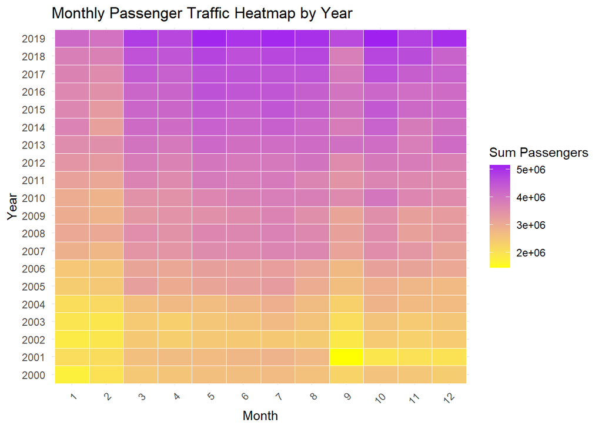

```r
# Create the heatmap
ggplot(heatmap_data, aes(x = factor(month), y = factor(year), fill = sum_passengers)) +
  geom_tile(color = "white") +  # Adds the tiles for the heatmap
  scale_fill_gradient(low = "yellow", high = "purple", name = "Sum Passengers") +  # Color gradient
  labs(title = "Monthly Passenger Traffic Heatmap by Year", x = "Month", y = "Year") +
  theme_minimal() +
  theme(axis.text.x = element_text(angle = 45, hjust = 1))  # Improve x-axis labels visibility
```

### FORECASTING

##Creating the time series object

**Checking if there any months no register in a year**

```r
# Group by year and summarize to count unique months per year
monthly_data_check <- df %>%
  group_by(year) %>%
  summarise(month_count = n_distinct(month)) %>%
  mutate(full_year_data = if_else(month_count == 12, "Yes", "No"))

# View the results
print(monthly_data_check)
```

```
## # A tibble: 20 × 3
##     year month_count full_year_data
##    <int>       <int> <chr>
##  1  2000          12 Yes
##  2  2001          12 Yes
##  3  2002          12 Yes
##  4  2003          12 Yes
##  5  2004          12 Yes
##  6  2005          12 Yes
##  7  2006          12 Yes
##  8  2007          12 Yes
##  9  2008          12 Yes
## 10  2009          12 Yes
## 11  2010          12 Yes
## 12  2011          12 Yes
## 13  2012          12 Yes
## 14  2013          12 Yes
## 15  2014          12 Yes
## 16  2015          12 Yes
## 17  2016          12 Yes
## 18  2017          12 Yes
## 19  2018          12 Yes
## 20  2019          12 Yes
```

Notice that all years have the 12 months.

**time series object**

```r
# Aggregate data to monthly frequency
monthly_df <- df %>%
  group_by(year, month) %>%
  summarize(sum_passengers = sum(sum_passengers), .groups = 'drop')

# Create time series object
ts_df <- ts(monthly_df$sum_passengers,
    start = c(min(monthly_df$year),
    min(monthly_df$month)),
    frequency = 12)
```

**Visualizing the ts_df, Monthly Total of Passengers**

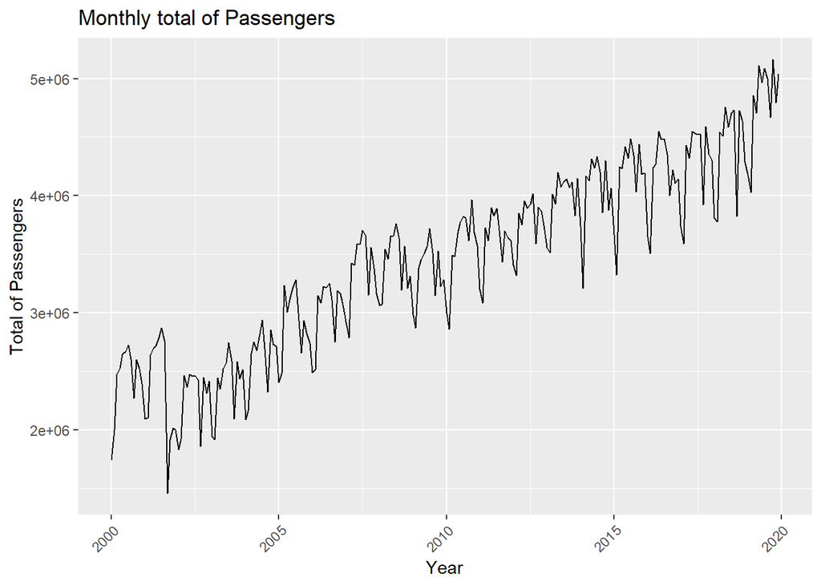

```r
autoplot(ts_df) +
  xlab("Year") +
  ylab("Total of Passengers") +
  ggtitle("Monthly total of Passengers") +
  theme(axis.text.x = element_text(angle = 45, hjust = 1))
```

**Train test split, 90% data is for train**

```r
N <- length(ts_df)
train_ratio <- 0.9
T <- floor(train_ratio*N)
S <- N - T
train <- head(ts_df, T)
test <- tail(ts_df, S)
```

**Visualizing the Train test split**

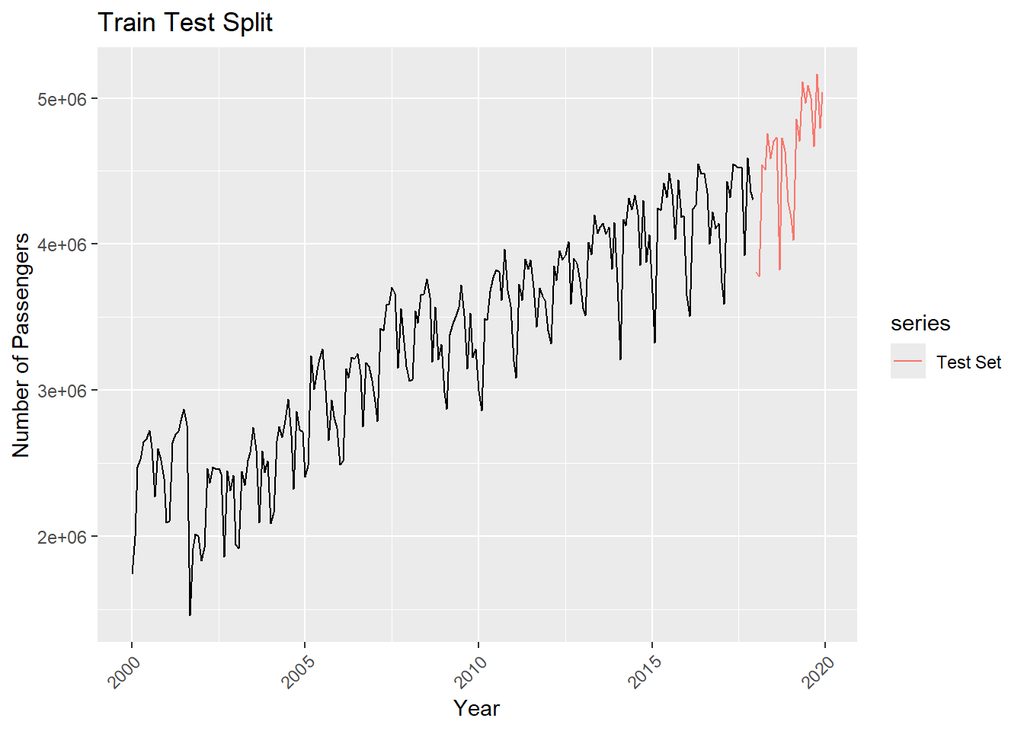

```r
autoplot(train) +
  autolayer(test, series = "Test Set") +
  xlab("Year") +
  ylab("Number of Passengers") +
  ggtitle("Train Test Split") +
  theme(axis.text.x = element_text(angle = 45, hjust = 1))
```

##Checking the seasonality of our ts object

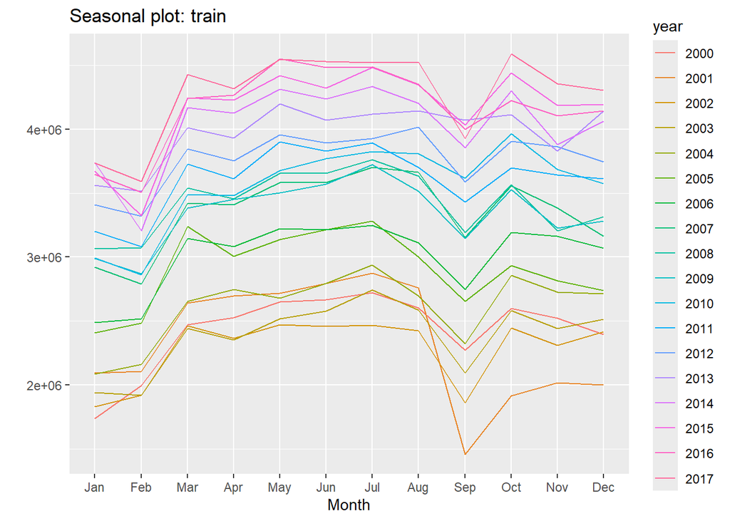

```r
ggseasonplot(train)
```

##Performing a decomposition Our goal is to understand the underlying components of our train set ts object.

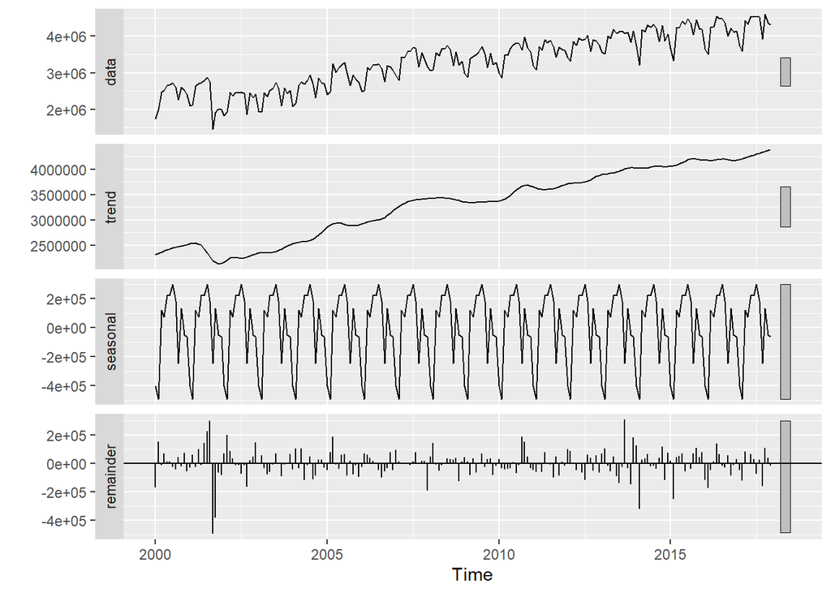

```r
train_stl <- stl(train, s.window = "periodic", t.window = 12)
autoplot(train_stl)
```

##Box.Cox Transform

We want to pick the lambda that stabilizes the variance the best for apply the box-cox transform with la first in our forecast functions.

```r
la <- BoxCox.lambda(train)
la
```

```
## [1] 1.127672
```

## Forecasting with different methods

#Naive forecast

```r
naive_forecast <- naive(train, lambda=la, h = S)
accuracy(naive_forecast, test)
```

```
##                     ME     RMSE      MAE        MPE     MAPE     MASE
## Training set  11936.57 304374.4 221841.3 -0.1478918 7.220260 1.196339
## Test set     300823.17 507856.0 460717.3  5.7301006 9.871906 2.484541
##                    ACF1 Theil's U
## Training set -0.2782278        NA
## Test set      0.4046188  1.112787
```

```r
naive_rmse <- accuracy(naive_forecast, test)["Test set", "RMSE"]
```

#Seasonal Naive forecast

```r
snaive_forecast <- snaive(train, lambda=la, h = S)
accuracy(snaive_forecast, test)
```

```
##                    ME     RMSE      MAE      MPE     MAPE     MASE      ACF1
## Training set 108931.4 232713.1 185433.5 2.986508 6.172547 1.000000 0.6846912
## Test set     322653.0 393043.9 332285.4 6.792431 7.040486 1.791938 0.5669365
##              Theil's U
## Training set        NA
## Test set     0.8649315
```

```r
snaive_rmse <- accuracy(snaive_forecast, test)["Test set", "RMSE"]
```

#Drift forecast

```r
drift_forecast <- rwf(train, lambda=la, drift = TRUE, h = S)
accuracy(drift_forecast, test)
```

```
##                       ME     RMSE      MAE        MPE     MAPE     MASE
## Training set    138.7344 304057.0 222624.6 -0.5251443 7.250946 1.200563
## Test set     159096.7278 398120.4 367214.6  2.7260989 8.052901 1.980303
##                    ACF1 Theil's U
## Training set -0.2782679        NA
## Test set      0.3003130 0.8787021
```

```r
drift_rmse <- accuracy(drift_forecast, test)["Test set", "RMSE"]
```

#Average forecast

```r
mean_forecast <- meanf(train, lambda=la, h = S)
accuracy(mean_forecast, test)
```

```
##                      ME      RMSE     MAE       MPE     MAPE     MASE      ACF1
## Training set  -10522.44  728628.1  619427 -6.068036 20.95812 3.340426 0.8980106
## Test set     1277934.02 1341841.4 1277934 27.132287 27.13229 6.891601 0.4046188
##              Theil's U
## Training set        NA
## Test set      3.006082
```

```r
mean_rmse <- accuracy(mean_forecast, test)["Test set", "RMSE"]
```

#Holt-winters

```r
hw_forecast <- hw(train, lambda=la, h = S)
accuracy(hw_forecast, test)
```

```
##                      ME     RMSE       MAE         MPE     MAPE      MASE
## Training set   6597.618 124543.9  86156.64 0.001745751 2.950183 0.4646227
## Test set     155765.581 281194.6 227025.20 2.999212155 4.830478 1.2242941
##                    ACF1 Theil's U
## Training set 0.06367737        NA
## Test set     0.46088394 0.6087398
```

```r
mean_rmse <- accuracy(hw_forecast, test)["Test set", "RMSE"]
```

#Selecting the best ETS model

```r
tr_best_ets <- ets(train, model = "ZZZ", ic = c("aicc", "aic", "bic"), lambda=la)
```

```r
summary(tr_best_ets)
```

```
## ETS(A,A,A)
##
## Call:
## ets(y = train, model = "ZZZ", lambda = la, ic = c("aicc", "aic",
##     "bic"))
##
##   Box-Cox transformation: lambda= 1.1277
##
##   Smoothing parameters:
##     alpha = 0.5138
##     beta  = 1e-04
##     gamma = 1e-04
##
##   Initial states:
##     l = 14704739.8335
##     b = 34598.6949
##     s = -471688.8 -447220.1 754257.6 -1679971 1164133 2006007
##            1518944 1611110 556299 939460 -3239083 -2712248
##
##   sigma:  861643.9
##
##      AIC     AICc      BIC
## 7082.407 7085.498 7139.786
##
## Training set error measures:
##                    ME     RMSE      MAE         MPE     MAPE      MASE
## Training set 6593.812 124543.6 86159.68 0.001676557 2.950283 0.4646391
##                    ACF1
## Training set 0.06342413
```

ETS model and testing set accuracy

```r
ets_forecast <- forecast(tr_best_ets, h = S)
accuracy(ets_forecast, test)
```

```
##                      ME     RMSE       MAE         MPE     MAPE      MASE
## Training set   6593.812 124543.6  86159.68 0.001676557 2.950283 0.4646391
## Test set     155753.047 281186.5 227017.21 2.998939771 4.830318 1.2242510
##                    ACF1 Theil's U
## Training set 0.06342413        NA
## Test set     0.46087904 0.6087214
```

```r
ets_rmse <- accuracy(ets_forecast, test)["Test set", "RMSE"]
```

Visualizing Best ETS Forecast

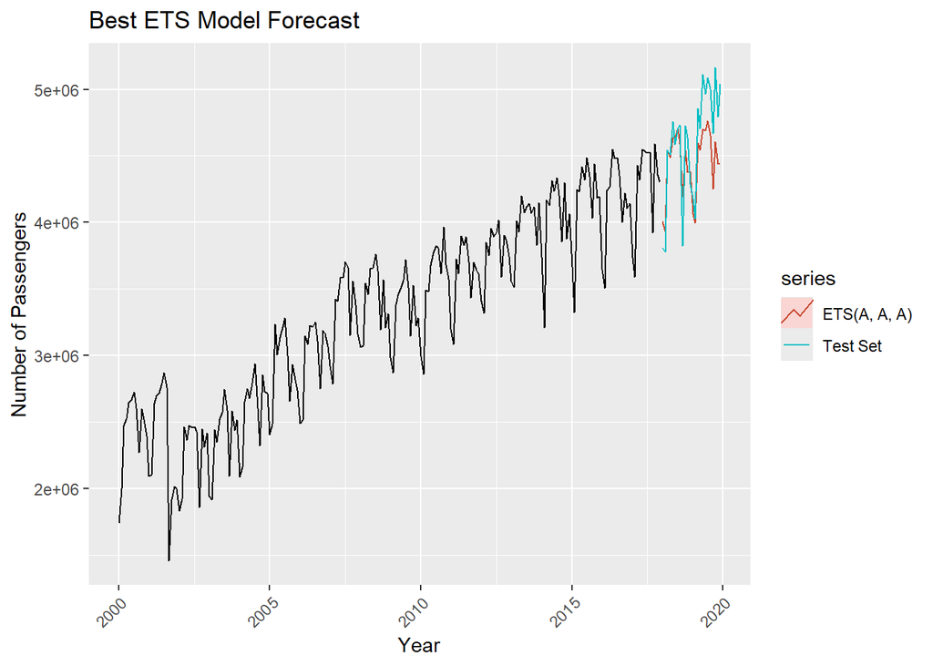

```r
autoplot(train) +  # windowing so we can see the prediction more clearly
  autolayer(ets_forecast, series = "ETS(A, A, A)", PI = F) +
  autolayer(test, series = "Test Set") +
  xlab("Year") +
  ylab("Number of Passengers") +
  ggtitle("Best ETS Model Forecast") +
  theme(axis.text.x = element_text(angle = 45, hjust = 1))
```

In the plot we can see that the forecast has a similar pattern to our test set.

#ARIMA models

*Checking if the data is stationary** Base on observation the times series is clearly not stationary, let’s check statistically.

```r
summary(ur.kpss(train))
```

```
##
## #######################
## # KPSS Unit Root Test #
## #######################
##
## Test is of type: mu with 4 lags.
##
## Value of test-statistic is: 4.1306
##
## Critical value for a significance level of:
##                 10pct  5pct 2.5pct  1pct
## critical values 0.347 0.463  0.574 0.739
```

Since the value of test statistic 4.1306 > 0.463 the value under 5% means this ts is NOT stationary.

**Turning our times series stationary**

Checking how many seasonal differencing are need in order to make a time series stationary.

```r
nsdiffs(log(train))
```

```
## [1] 1
```

We run a kpss test on the seasonally differenced series.

```r
kpss_results <- ur.kpss(diff(train, lag=frequency(train)))
summary(kpss_results)
```

```
##
## #######################
## # KPSS Unit Root Test #
## #######################
##
## Test is of type: mu with 4 lags.
##
## Value of test-statistic is: 0.1466
##
## Critical value for a significance level of:
##                 10pct  5pct 2.5pct  1pct
## critical values 0.347 0.463  0.574 0.739
```

Since the value of test statistic 0.1466 < 0.463 the value under 5% means this ts is stationary after the first seasonal differencing.

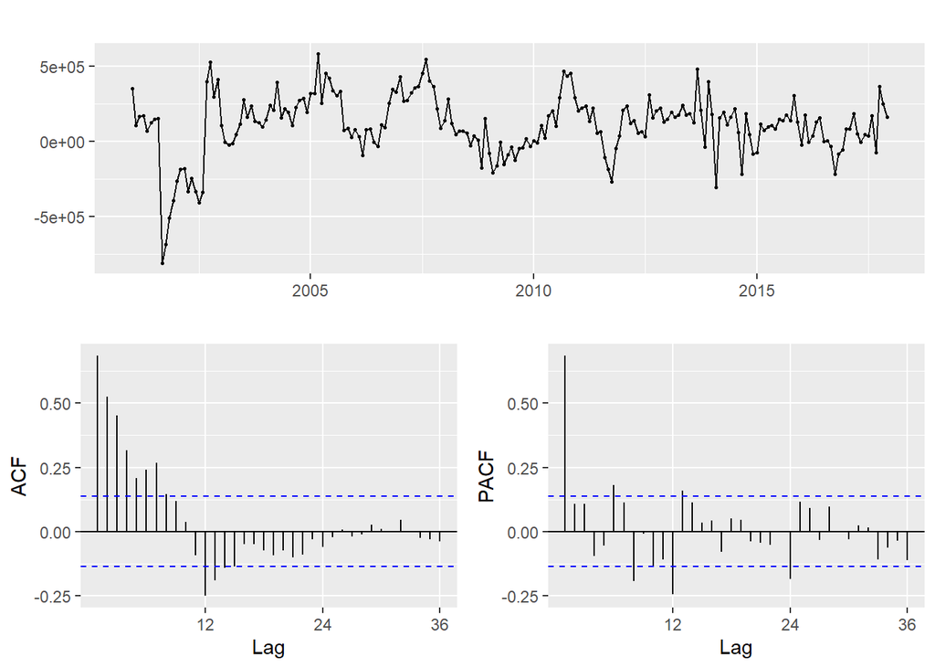

```r
ggtsdisplay(diff(train, lag = frequency(train)))
```

ACF Plot (Bottom Left Panel): There are significant autocorrelations at initial lags (notably at lag 1 through 7), which gradually decay, indicating a possible AR (autoregressive) process. A notable spike at lag 12 suggests a potential yearly seasonal effect, as this autocorrelation persists over a significant period.

PACF Plot (Bottom Right Panel): A significant spike at lag 1 indicates a strong AR(1) component is likely present in the data. Spikes at lags 12 and 24 suggest seasonal effects that may require a seasonal ARIMA model to account for yearly patterns observed at consistent intervals.

#AUTO ARIMA MODELS

**ARIMA 1:**

We use auto.arima() to pick the best one among all arima models with variations in the penalty.

```r
arima1 <- auto.arima(train, lambda=la, seasonal = TRUE, ic="aic", stepwise = FALSE, d=0, D=1)
arima1
```

```
## Series: train
## ARIMA(1,0,1)(2,1,1)[12] with drift
## Box Cox transformation: lambda= 1.127672
##
## Coefficients:
##          ar1      ma1    sar1     sar2     sma1      drift
##       0.8711  -0.3289  0.0403  -0.0508  -0.7172  69592.891
## s.e.  0.0492   0.0974  0.1279   0.1104   0.1071   8091.438
##
## sigma^2 = 6.983e+11:  log likelihood = -3072.79
## AIC=6159.57   AICc=6160.15   BIC=6182.8
```

```r
arima_forecast <- forecast(arima1, h = S)
accuracy(arima_forecast, test)
```

```
##                     ME     RMSE       MAE        MPE     MAPE      MASE
## Training set -3818.985 119641.0  83389.97 -0.3545059 2.788057 0.4497027
## Test set     94407.155 208578.9 164854.33  1.7777714 3.547351 0.8890211
##                    ACF1 Theil's U
## Training set 0.03036219        NA
## Test set     0.34232132 0.4495678
```

```r
arima1_rmse <- accuracy(arima_forecast, test)["Test set", "RMSE"]
```

Indeed, the auto.arima function chose the AR model with the seasonal component.

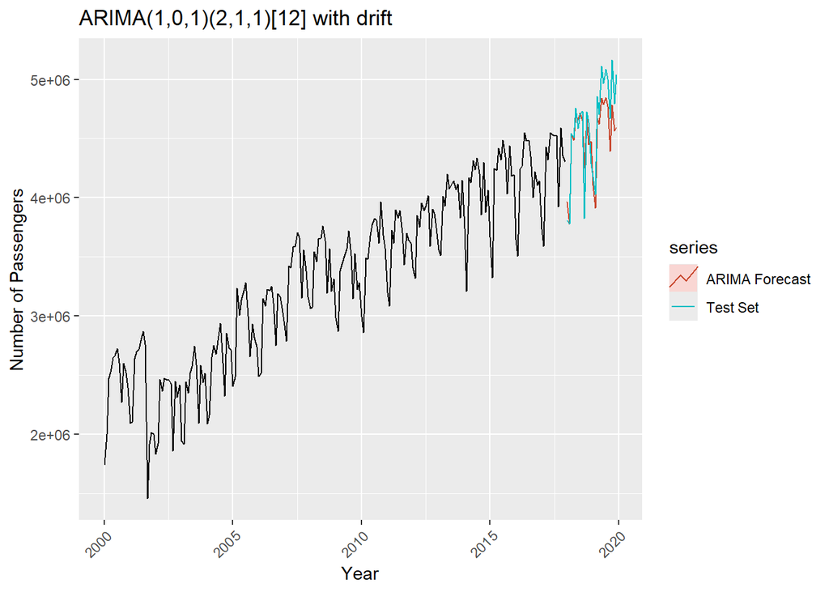

```r
autoplot(train) +
  autolayer(arima_forecast, series = "ARIMA Forecast", PI=F) +
  autolayer(test, series = "Test Set") +
  xlab("Year") +
  ylab("Number of Passengers") +
  ggtitle("ARIMA(1,0,1)(2,1,1)[12] with drift ") +
  theme(axis.text.x = element_text(angle = 45, hjust = 1))
```

**ARIMA 2:** Changing the ic criterion and using a the approximation to FALSE, forcing the function to use a slower but more accurate fitting method.

```r
arima2 <- auto.arima(train, lambda=la, seasonal = TRUE, ic="bic", stepwise = FALSE,
                     d=0, D=1, approximation = FALSE)
arima2
```

```
## Series: train
## ARIMA(1,0,1)(0,1,1)[12] with drift
## Box Cox transformation: lambda= 1.127672
##
## Coefficients:
##          ar1      ma1     sma1      drift
##       0.8789  -0.3439  -0.7119  69144.818
## s.e.  0.0454   0.0929   0.0569   8554.303
##
## sigma^2 = 6.941e+11:  log likelihood = -3073.08
## AIC=6156.15   AICc=6156.46   BIC=6172.74
```

```r
arima2_forecast <- forecast(arima2, h = S)
accuracy(arima2_forecast, test)
```

```
##                      ME     RMSE      MAE        MPE     MAPE      MASE
## Training set  -3672.582 119829.8  84685.9 -0.3494371 2.827757 0.4566914
## Test set     103649.526 213914.6 171591.7  1.9817717 3.690443 0.9253541
##                    ACF1 Theil's U
## Training set 0.02990231        NA
## Test set     0.33335629 0.4624915
```

```r
arima2_rmse <- accuracy(arima2_forecast, test)["Test set", "RMSE"]
```

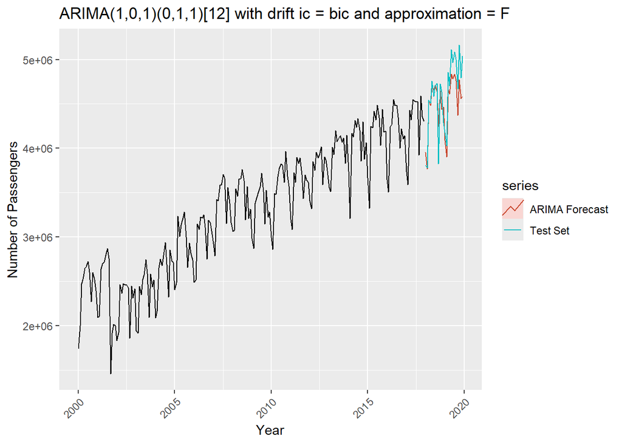

```r
autoplot(train) +
  autolayer(arima2_forecast, series = "ARIMA Forecast", PI=F) +
  autolayer(test, series = "Test Set") +
  xlab("Year") +
  ylab("Number of Passengers") +
  ggtitle("ARIMA(1,0,1)(0,1,1)[12] with drift ic = bic and approximation = F") +
  theme(axis.text.x = element_text(angle = 45, hjust = 1))
```

# Choosing a final model for Forecasting

```r
rmses <- data.frame(mean_rmse, naive_rmse, snaive_rmse, drift_rmse, ets_rmse, arima1_rmse, arima2_rmse)
rmses
```

| mean_rmse | naive_rmse | snaive_rmse | drift_rmse | ets_rmse | arima1_rmse | arima2_rmse |
| --- | --- | --- | --- | --- | --- | --- |
| 281194.6 | 507856 | 393043.9 | 398120.4 | 281186.5 | 208578.9 | 213914.6 |

The first arima model has the lowest testing RMSE. The candidates are: 1. arima1 2. arima2 3. ets

Let’s see all the models in a plot

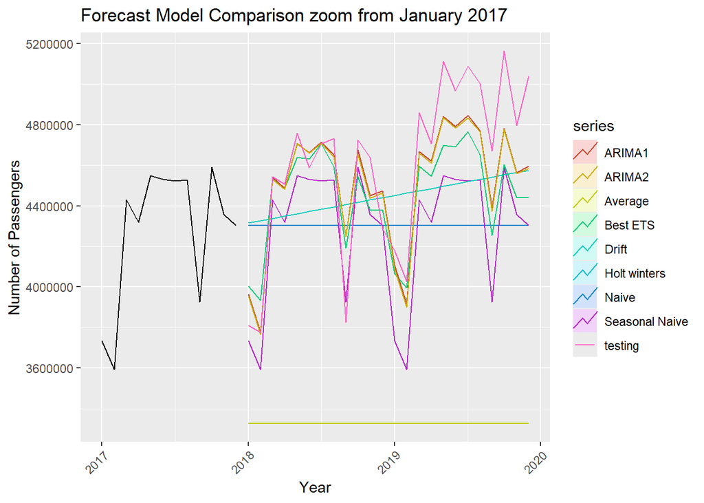

```r
autoplot(window(train, start = c(2017,1))) +
  autolayer(naive_forecast, series = "Naive", PI = F) +
  autolayer(snaive_forecast, series = "Seasonal Naive", PI = F) +
  autolayer(drift_forecast, series = "Drift", PI = F) +
  autolayer(mean_forecast, series = "Average", PI = F) +
  autolayer(hw_forecast, series = "Holt winters", PI = F) +
  autolayer(ets_forecast, series = "Best ETS", PI = F) +
  autolayer(arima_forecast, series = "ARIMA1", PI = F) +
  autolayer(arima2_forecast, series = "ARIMA2", PI = F) +
  autolayer(test, series = "testing")+
  xlab("Year") +
  ylab("Number of Passengers") +
  ggtitle("Forecast Model Comparison zoom from January 2017") +
  theme(axis.text.x = element_text(angle = 45, hjust = 1))
```

#Checking residuals of these models

```r
L <- min(ceiling(T/5), 2*frequency(train))
```

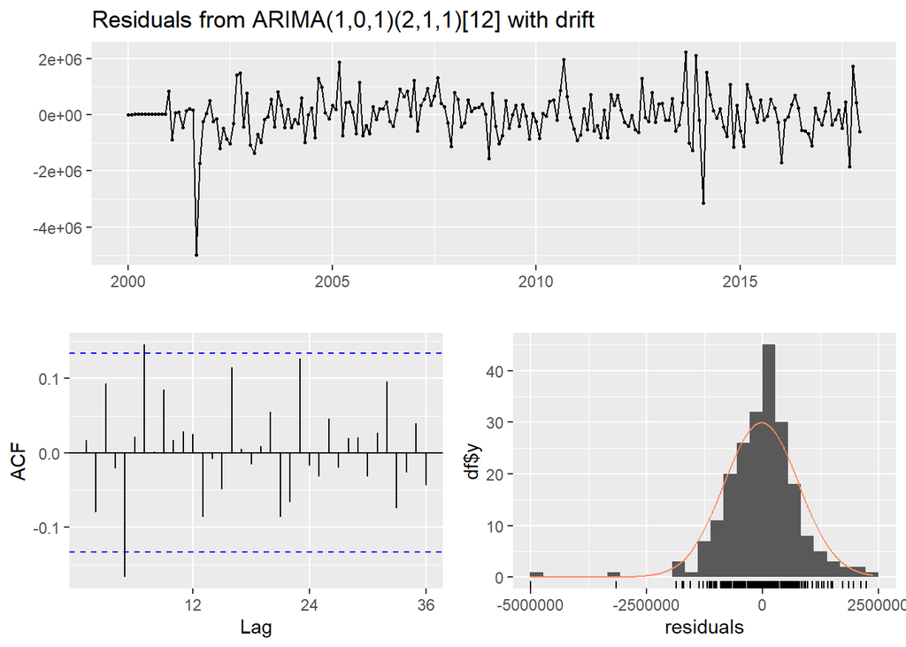

```
##
##  Ljung-Box test
##
## data:  Residuals from ARIMA(1,0,1)(2,1,1)[12] with drift
## Q* = 29.633, df = 19, p-value = 0.05666
##
## Model df: 5.   Total lags used: 24
```

```r
checkresiduals(arima1, lag = L)
```

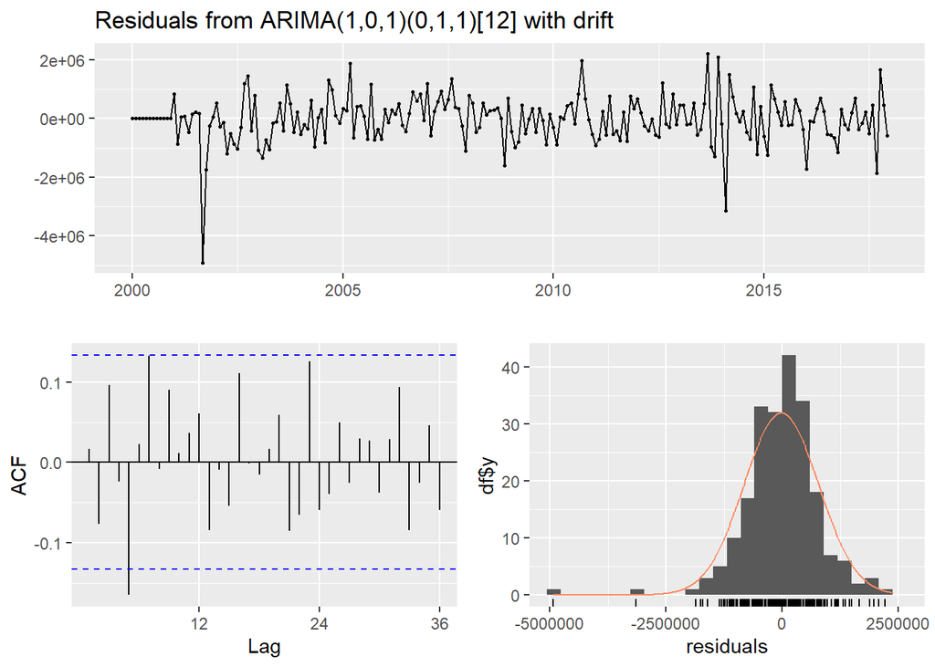

```
##
##  Ljung-Box test
##
## data:  Residuals from ARIMA(1,0,1)(0,1,1)[12] with drift
## Q* = 30.634, df = 21, p-value = 0.07997
##
## Model df: 3.   Total lags used: 24
```

```r
checkresiduals(arima2, lag = L)
```

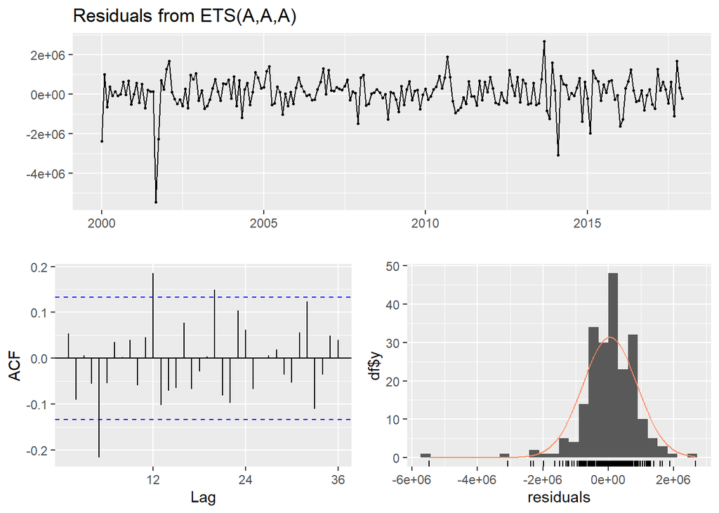

```
##
##  Ljung-Box test
##
## data:  Residuals from ETS(A,A,A)
## Q* = 44.125, df = 24, p-value = 0.007378
##
## Model df: 0.   Total lags used: 24
```

```r
checkresiduals(tr_best_ets, lag = L)
```

#Cross validation in our models

```r
arima1_cv <- function(y, h) {
  # Fit an ARIMA model to the data segment 'y'
  model <- Arima(y, order = c(1, 0, 1), seasonal = c(2, 1, 1))
  # Return the forecast over a horizon 'h'
  return(forecast(model, h = h))
}

# Perform cross-validation
arima1_cv_results <- tsCV(ts_df, arima1_cv, h = S)

# Calculate RMSE from the cross-validation results
arima1_cv_rmse <- sqrt(mean(arima1_cv_results^2, na.rm = TRUE))
```

```r
arima2_cv <- function(y, h) {
  # Fit an ARIMA model to the data segment 'y'
  model <- Arima(y, order = c(1, 0, 1), seasonal = c(0, 1, 1))
  # Return the forecast over a horizon 'h'
  return(forecast(model, h = h))
}

# Perform cross-validation
arima2_cv_results <- tsCV(ts_df, arima2_cv, h = S)

# Calculate RMSE from the cross-validation results
arima2_cv_rmse <- sqrt(mean(arima2_cv_results^2, na.rm = TRUE))
```

```r
ets_cv <- function(y, h){
  model <- ets(y, model="AAA")
  return(forecast(model, h = h))
}

ets_cv_results <- tsCV(ts_df, ets_cv, h = S)
ets_cv_rmse <- sqrt(mean(ets_cv_results^2, na.rm = TRUE))
```

```r
cv_rmses <- data.frame(arima1_cv_rmse, arima2_cv_rmse, ets_cv_rmse)
cv_rmses
```

| arima1_cv_rmse | arima2_cv_rmse | ets_cv_rmse |
| --- | --- | --- |
| 288784.5 | 288072.5 | 631790.2 |

##MODEL SELECTED

**arima1 is the model selected, base on:**

-Alignment with Course Methods: ARIMA1 uses default settings like approximation=TRUE, aligning with methodologies taught in class.

-Good In-Sample Performance: ARIMA1 shows superior in-sample RMSE, indicating a better fit to training data.

-Competitive Cross-Validation Performance: Though ARIMA1’s cross-validation RMSE is slightly higher than ARIMA2’s, the difference is minimal. This closeness in performance suggests that ARIMA1 generalizes adequately to unseen data.

-Practicality and Computational Efficiency: The use of approximation=TRUE speeds up the model fitting process, especially beneficial for large datasets.This approach reduces computational demands without substantially compromising accuracy.

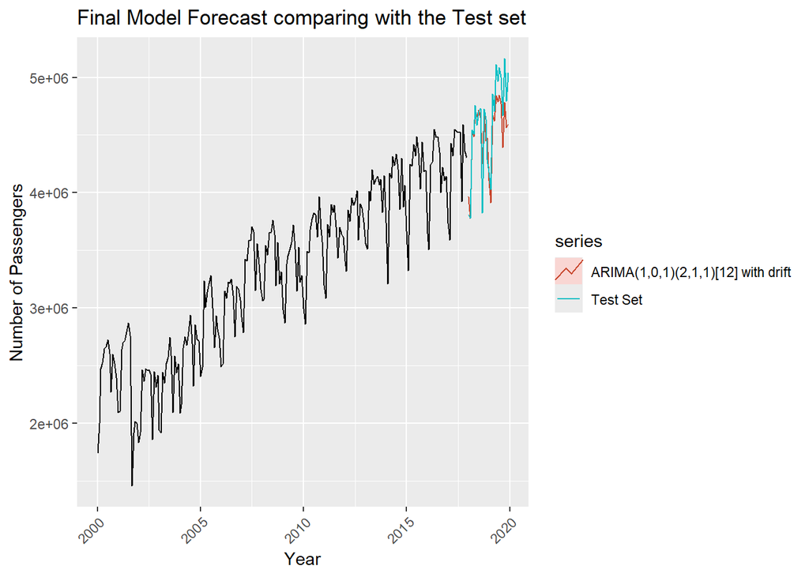

```r
autoplot(train) +
  autolayer(forecast(arima1, h = S), series = "ARIMA(1,0,1)(2,1,1)[12] with drift", PI = F) +
  autolayer(test, series = "Test Set") +
  xlab("Year") +
  ylab("Number of Passengers") +
  ggtitle("Final Model Forecast comparing with the Test set") +
  theme(axis.text.x = element_text(angle = 45, hjust = 1))
```

### Forecasting 2020 data

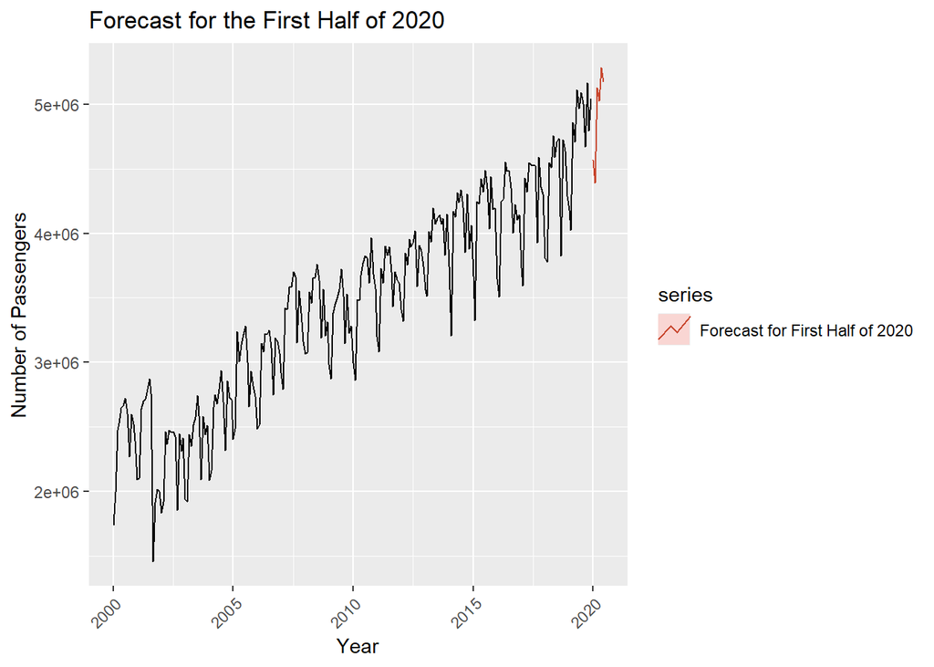

```r
# Fit the ARIMA model
arima_final <- Arima(ts_df, order=c(1,0,1), seasonal=c(2,1,1), include.drift=TRUE, lambda=la)

# Generate forecasts for the first half of 2020
future_forecast <- forecast(arima_final, h=6)

# Plotting the forecast along with the training data
# Since there is no actual test data for 2020, we only plot the forecast
autoplot(ts_df) +
  autolayer(future_forecast, series = "Forecast for First Half of 2020", PI = FALSE) +
  xlab("Year") +
  ylab("Number of Passengers") +
  ggtitle("Forecast for the First Half of 2020") +
  theme(axis.text.x = element_text(angle = 45, hjust = 1))
```

```r
forecast_table <- data.frame(
  Month = seq(as.Date("2020-01-01"), by = "month", length.out = 6),
  Forecasted_Passengers = round(future_forecast$mean),
  Lower_95 = round(future_forecast$lower[,2]),
  Upper_95 = round(future_forecast$upper[,2])
)

print(forecast_table)
```

```
##        Month Forecasted_Passengers Lower_95 Upper_95
## 1 2020-01-01               4567622  4322334  4811238
## 2 2020-02-01               4389766  4117390  4659999
## 3 2020-03-01               5126686  4840709  5410640
## 4 2020-04-01               5025187  4723591  5324489
## 5 2020-05-01               5282171  4970933  5591084
## 6 2020-06-01               5169308  4847909  5488174
```

The ARIMA model specified is $ARIMA(1,0,1)(2,1,1)[12]$ with drift. A Box Cox transformation is applied with $\lambda = 1.127672$.

### SPATIAL ANALYSIS

#Creating a new data frame just for take the geolocations

```r
#city_names <- df %>%
#  select(origin_city_name, dest_city_name) %>%
#  unlist() %>%
#  unique()

# Create a new dataframe with the unique city names
#new_df <- data.frame(city_name = city_names)

# Print the new dataframe to see the result
#print(new_df)
```

#Using API google maps to take the geolocations

```r
#install.packages("ggmap")
#library(ggmap)
```

```r
#register_google(key = "Replace Here")
```

```r
# Geocode each city to find latitude and longitude
#new_df$city_name <- as.character(new_df$city_name)
#coords <- geocode(new_df$city_name, output = "latlona", source = "google")

# Check for any geocoding errors
#if (any(is.na(coords$lon) | is.na(coords$lat))) {
#  warning("Some coordinates were not found")
#}

# Add coordinates to the original dataframe
#new_df <- bind_cols(new_df, coords[, c("lon", "lat")])
```

```r
#new_df
```

#Writing the data frame with geocodes that is no necessary another call of the API google

```r
# Write the new_df to a CSV file in the Data folder
#write.csv(new_df, "Data/geocodes_df.csv", row.names = FALSE)
```

```r
geocodes <- read.csv("Data/geocodes_df.csv")
```

Pasting geolocations in our data set, the data is divided in 2 data set base on if the flights are coming from or going to Charlotte, NC or Raleigh/Durham, NC.

```r
colnames(geocodes)
```

```
## [1] "city_name" "lon"       "lat"
```

```r
# Flights originating from Charlotte or Raleigh
flights_from_char_raleigh <- df %>%
  filter(origin_city_name %in% c("Charlotte, NC", "Raleigh/Durham, NC"))

# Flights destined for Charlotte or Raleigh
flights_to_char_raleigh <- df %>%
  filter(dest_city_name %in% c("Charlotte, NC", "Raleigh/Durham, NC"))
```

```r
flights_from_char_raleigh <- flights_from_char_raleigh %>%
  left_join(geocodes, by = c("dest_city_name" = "city_name"))

flights_to_char_raleigh <- flights_to_char_raleigh %>%
  left_join(geocodes, by = c("origin_city_name" = "city_name"))
```

*Checking Final Data sets for create the map.*

```r
colnames(flights_from_char_raleigh)
```

```
##  [1] "sum_passengers"      "airline_id"          "carrier_name"
##  [4] "origin"              "origin_city_name"    "origin_state_abr"
##  [7] "origin_state_nm"     "origin_country"      "origin_country_name"
## [10] "dest"                "dest_city_name"      "dest_state_abr"
## [13] "dest_state_nm"       "dest_country"        "dest_country_name"
## [16] "year"                "month"               "lon"
## [19] "lat"
```

```r
colnames(flights_to_char_raleigh)
```

```
##  [1] "sum_passengers"      "airline_id"          "carrier_name"
##  [4] "origin"              "origin_city_name"    "origin_state_abr"
##  [7] "origin_state_nm"     "origin_country"      "origin_country_name"
## [10] "dest"                "dest_city_name"      "dest_state_abr"
## [13] "dest_state_nm"       "dest_country"        "dest_country_name"
## [16] "year"                "month"               "lon"
## [19] "lat"
```

```r
# Checking NaN values in specific longitude and latitude columns
missing_from_lo <- sum(is.na(flights_from_char_raleigh$lon))
missing_from_la <- sum(is.na(flights_from_char_raleigh$lat))
missing_to_lo <- sum(is.na(flights_to_char_raleigh$lon))
missing_to_la <- sum(is.na(flights_to_char_raleigh$lat))

# Print the number of missing values for each column
cat("Missing values from Charlotte and Raleigh: ", missing_from_lo, "\n")
```

```
## Missing values from Charlotte and Raleigh:  0
```

```r
cat("Missing values from Charlotte and Raleigh: ", missing_from_la, "\n")
```

```
## Missing values from Charlotte and Raleigh:  0
```

```r
cat("Missing values to Charlotte and Raleigh: ", missing_to_lo, "\n")
```

```
## Missing values to Charlotte and Raleigh:  0
```

```r
cat("Missing values to Charlotte and Raleigh: ", missing_to_la, "\n")
```

```
## Missing values to Charlotte and Raleigh:  0
```

Write the data frames to CSV file in the Data folder to make interactive map in shiny

```r
#write.csv(flights_from_char_raleigh, "Data/from_char_raleigh.csv", row.names = FALSE)
#write.csv(flights_to_char_raleigh, "Data/to_char_raleigh.csv", row.names = FALSE)
```

*Creating sf objects for future plots*

```r
#install.packages("sf")
library(sf)
usa_sf <- st_read("Data/sf/cb_2018_us_state_5m.shp")
# Create an sf object for flights coming from Charlotte, NC or Raleigh/Durham, NC
flights_from_char_ral_sf <- st_as_sf(flights_from_char_raleigh, coords = c("lon", "lat"),
                              crs = "+proj=longlat +ellps=WGS84 +datum=WGS84 +no_defs")

# Create an sf object for flights going to Charlotte, NC or Raleigh/Durham, NC
flights_to_char_ral_sf <- st_as_sf(flights_to_char_raleigh, coords = c("lon", "lat"),
                            crs = "+proj=longlat +ellps=WGS84 +datum=WGS84 +no_defs")
```

##Maps

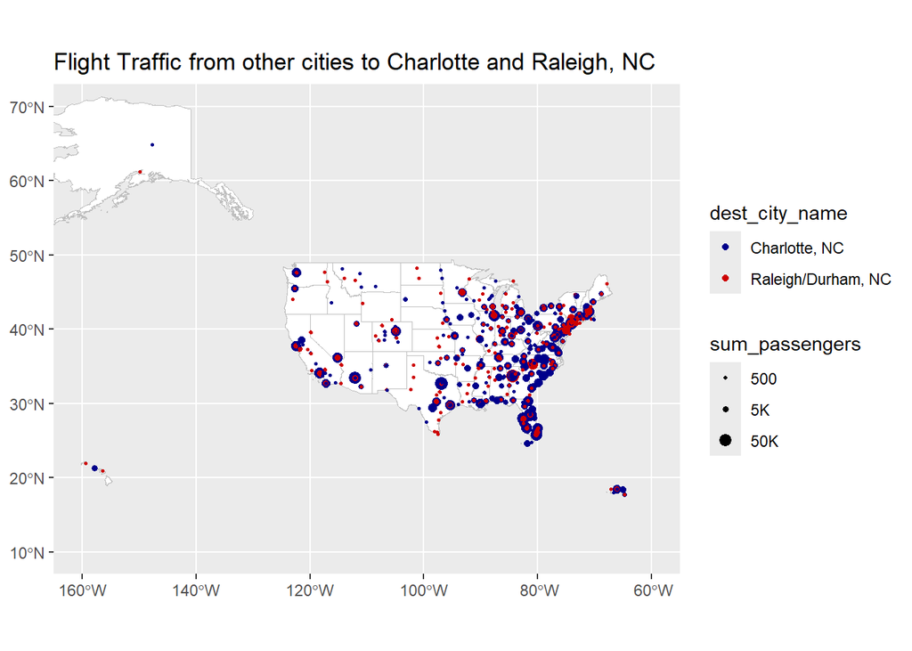

```r
ggplot() +
  geom_sf(data = usa_sf, fill = "white", color = "gray") +
  geom_sf(data = flights_to_char_ral_sf, aes(color = dest_city_name, size = sum_passengers)) +
  scale_color_manual(values = c("Charlotte, NC" = "blue4", "Raleigh/Durham, NC" = "red3")) +
  scale_size(range = c(0.5, 3), breaks = c(500, 5000, 50000), labels = c("500", "5K", "50K")) +
  labs(title = "Flight Traffic from other cities to Charlotte and Raleigh, NC") +
  coord_sf(xlim = c(-160, -60), ylim = c(10, 70))
```

```r
flight_counts <- table(flights_to_char_ral_sf$origin_state_abr)
flight_counts
```

```
##
##   AK   AL   AR   AZ   CA   CO   CT   DE   FL   GA   HI   IA   ID   IL   IN   KS
##   32 1762  730 1227 4108 1378 1323   35 9930 3796   48  347  105 3482 2336  107
##   KY   LA   MA   MD   ME   MI   MN   MO   MS   MT   NC   ND   NE   NH   NJ   NM
## 3510 1458 1970 1760  559 2991 1948 2834  917  162 7579   79  463  753 2838  287
##   NV   NY   OH   OK   OR   PA   PR   RI   SC   SD   TN   TX   UT   VA   VI   VT
## 1017 8088 4519  615  367 5542  503 1035 4084   61 5109 5826  604 7507  383  169
##   WA   WI   WV   WY
##  729 1056  906   10
```

```r
usa_sf2 <- st_read("Data/sf/cb_2018_us_state_5m.shp")
# Convert the flight_counts table to a data frame for easier merging
flight_counts_df <- as.data.frame(flight_counts)
names(flight_counts_df) <- c("STUSPS", "flightCounts")

# Merge with the spatial data frame
usa_sf2 <- merge(usa_sf2, flight_counts_df, by = "STUSPS", all.x = TRUE)

# Replace NA values with 0 in flightCounts if any state has no flights
usa_sf2$flightCounts[is.na(usa_sf2$flightCounts)] <- 0
```

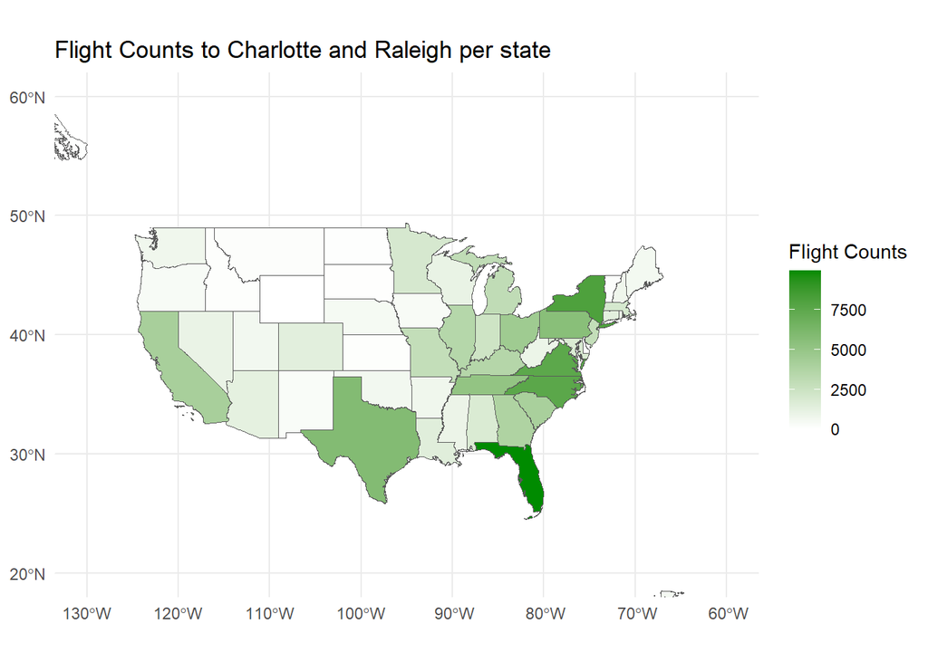

```r
# Plot using geom_sf
ggplot(data = usa_sf2) +
  geom_sf(aes(fill = flightCounts)) +
  scale_fill_gradient(low = "white", high = "green4", na.value = "grey", name = "Flight Counts") +
  labs(title = "Flight Counts to Charlotte and Raleigh per state", fill = "Flight Counts") +
  coord_sf(xlim = c(-130, -60), ylim = c(20, 60))+
  theme_minimal()
```

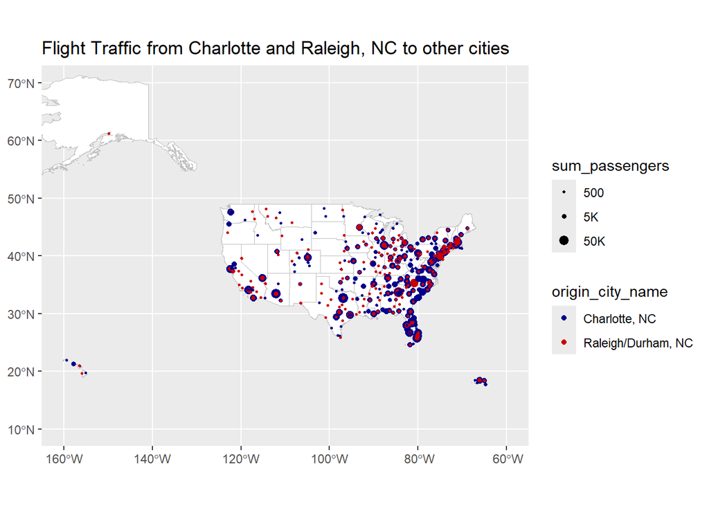

```r
ggplot() +
  geom_sf(data = usa_sf, fill = "white", color = "gray") +
  geom_sf(data = flights_from_char_ral_sf, aes(color = origin_city_name, size = sum_passengers)) +
  scale_color_manual(values = c("Charlotte, NC" = "blue4", "Raleigh/Durham, NC" = "red3")) +
  scale_size(range = c(0.5, 3), breaks = c(500, 5000, 50000), labels = c("500", "5K", "50K")) +
  labs(title = "Flight Traffic from Charlotte and Raleigh, NC to other cities") +
  coord_sf(xlim = c(-160, -60), ylim = c(10, 70))
```

```r
flight_counts2 <- table(flights_from_char_ral_sf$dest_state_abr)
flight_counts2
```

```
##
##   AK   AL   AR   AZ   CA   CO   CT   DE   FL   GA   HI   IA   ID   IL   IN   KS
##   22 1857  757 1146 4231 1363 1299   40 9617 3912  106  330  124 3451 2559  123
##   KY   LA   MA   MD   ME   MI   MN   MO   MS   MT   NC   ND   NE   NH   NJ   NM
## 3642 1636 2039 1787  556 3102 2058 2984  919  119 7517   49  437  762 2868  337
##   NV   NY   OH   OK   OR   PA   PR   RI   SC   SD   TN   TX   UT   VA   VI   VT
## 1036 8163 4759  654  381 5672  495 1071 4007   70 5260 6070  654 7551  371  176
##   WA   WI   WV   WY
##  835 1162  918   10
```

```r
usa_sf3 <- st_read("Data/sf/cb_2018_us_state_5m.shp")
# Convert the flight_counts table to a data frame for easier merging
flight_counts_df2 <- as.data.frame(flight_counts2)
names(flight_counts_df2) <- c("STUSPS", "flightCounts2")

# Merge with the spatial data frame
usa_sf3 <- merge(usa_sf3, flight_counts_df2, by = "STUSPS", all.x = TRUE)

# Replace NA values with 0 in flightCounts if any state has no flights
usa_sf3$flightCounts2[is.na(usa_sf3$flightCounts2)] <- 0
```

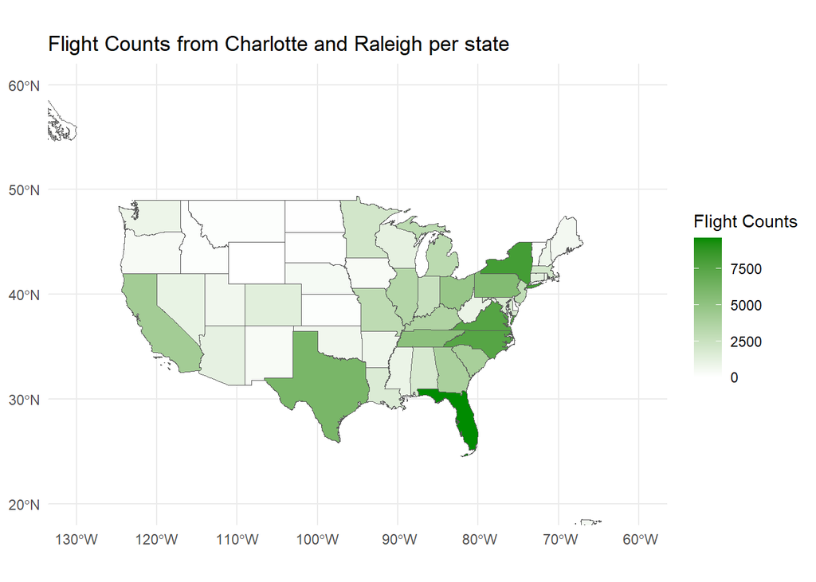

```r
# Plot using geom_sf
ggplot(data = usa_sf3) +
  geom_sf(aes(fill = flightCounts2)) +
  scale_fill_gradient(low = "white", high = "green4", na.value = "grey", name = "Flight Counts") +
  labs(title = "Flight Counts from Charlotte and Raleigh per state", fill = "Flight Counts") +
  coord_sf(xlim = c(-130, -60), ylim = c(20, 60))+
  theme_minimal()
```